# ashishsa_hw5_p2

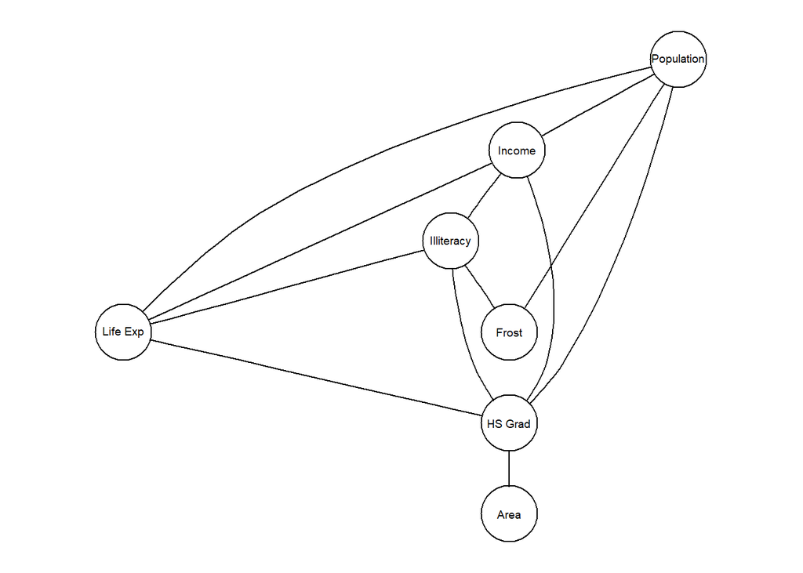

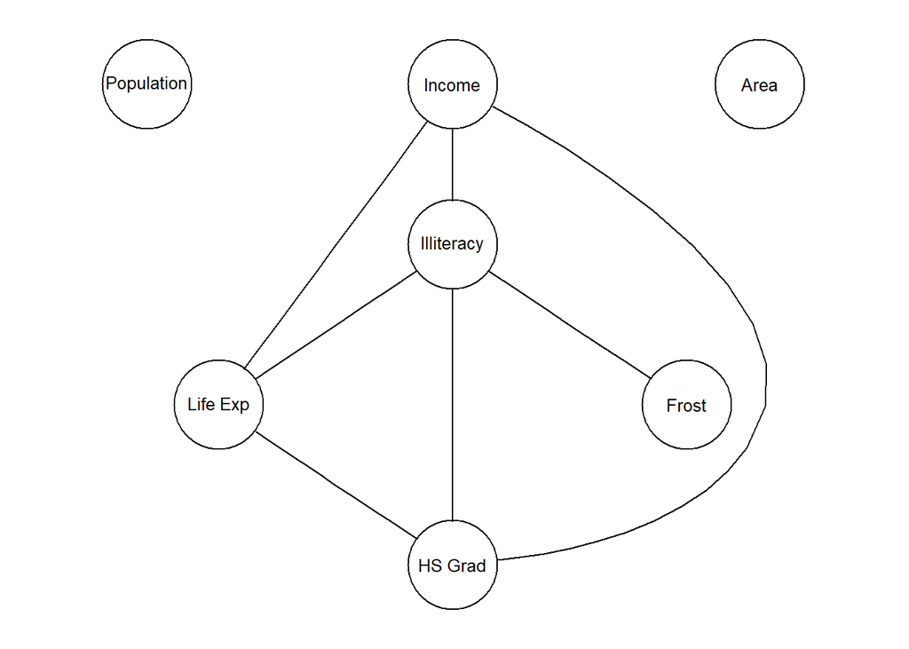

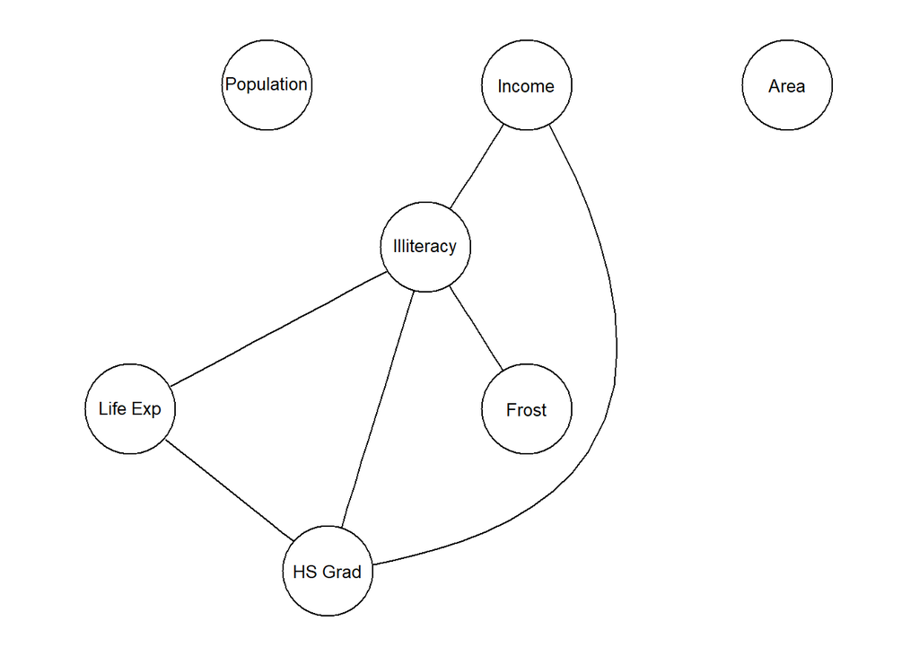

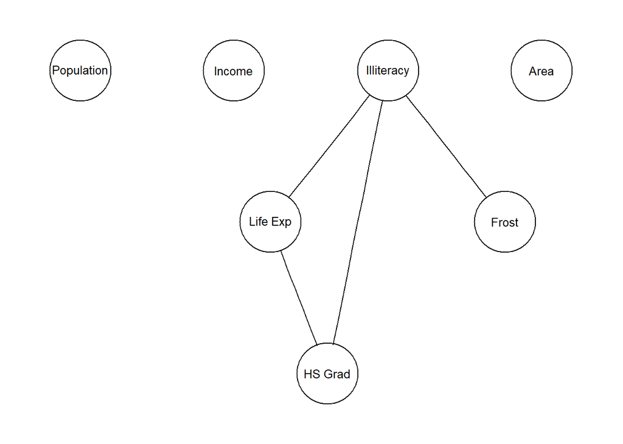

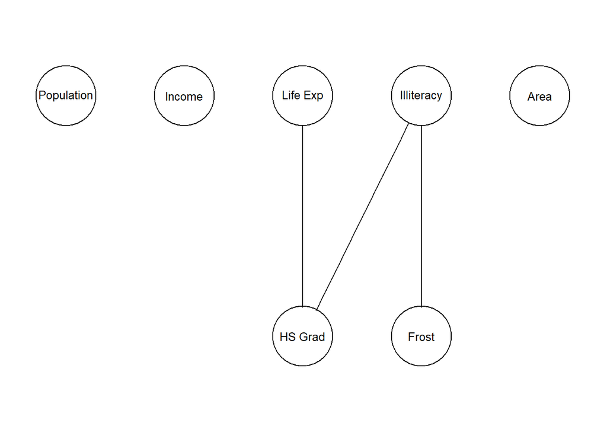

```r
for(i in 1:length(my_rhos)){
  my_edges <- m0.lasso$wi[ , , i]!= 0
  diag(my_edges) <- 0
  g.lasso <- as(my_edges,"graphNEL")
  nodes(g.lasso)<-colnames(new_dats)

  plot(g.lasso)
}
```

The Gaussian Graphical Models consider the Principal Components of the data to cluster the data. It uses the covariance and the partial covariance to cluster the data while the Heirarchical Cluster uses the Linkage distance to cluster the factors. The Gaussian Graphical Model can generally map the cause while Hclust is generally used to map the Result. Due to the nature of the mechanism of Gaussian Graphical Models are highly affected by the Skewedness of the data. The data needs to be Normalised before use. Otherwise the Gaussian Graphical Model is unable to cluster the data accurately. Heirarchical cluster is better than the Gaussian Graphical Model in this respect. It is not adversely affected by the nature of distribution of data.